# Homework 2: Sampling and Iteration

Mickayla Johnston

9/21/2020

#### 1. Some Data with Flippers

##### 1a. Load the library palmerpenguins after installing it.

```r
#install.packages("palmerpenguins")
library(palmerpenguins)
data("penguins")
```

##### 1b. Show the head of the dataset penguins

```r
head(penguins)
```

```
## # A tibble: 6 x 8
##   species island bill_length_mm bill_depth_mm flipper_length_… body_mass_g sex
##   <fct>   <fct>           <dbl>         <dbl>            <int>       <int> <fct>
## 1 Adelie  Torge…           39.1          18.7              181        3750 male
## 2 Adelie  Torge…           39.5          17.4              186        3800 fema…
## 3 Adelie  Torge…           40.3          18                195        3250 fema…
## 4 Adelie  Torge…           NA            NA                 NA          NA <NA>
## 5 Adelie  Torge…           36.7          19.3              193        3450 fema…
## 6 Adelie  Torge…           39.3          20.6              190        3650 male
## # … with 1 more variable: year <int>
```

##### 1c. What do you learn by using str() and summary() on penguins()

```r
str(penguins)
```

```
## tibble [344 × 8] (S3: tbl_df/tbl/data.frame)
##  $ species          : Factor w/ 3 levels "Adelie","Chinstrap",..: 1 1 1 1 1 1 1 1 1 1 ...
##  $ island           : Factor w/ 3 levels "Biscoe","Dream",..: 3 3 3 3 3 3 3 3 3 3 ...
##  $ bill_length_mm   : num [1:344] 39.1 39.5 40.3 NA 36.7 39.3 38.9 39.2 34.1 42 ...
##  $ bill_depth_mm    : num [1:344] 18.7 17.4 18 NA 19.3 20.6 17.8 19.6 18.1 20.2 ...
##  $ flipper_length_mm: int [1:344] 181 186 195 NA 193 190 181 195 193 190 ...
##  $ body_mass_g      : int [1:344] 3750 3800 3250 NA 3450 3650 3625 4675 3475 4250 ...
##  $ sex              : Factor w/ 2 levels "female","male": 2 1 1 NA 1 2 1 2 NA NA ...
##  $ year             : int [1:344] 2007 2007 2007 2007 2007 2007 2007 2007 2007 2007 ...
```

From str I can see that there are NAs in the columns bill_length_mm, bill_depth_mm, flipper_length_mm, body_mass_g, and sex. I can also see what class each column is, the levels of each factor column, and the range of each numeric and integer column.

```r
summary(penguins)
```

```
##       species          island    bill_length_mm  bill_depth_mm
##  Adelie   :152   Biscoe   :168   Min.   :32.10   Min.   :13.10
##  Chinstrap: 68   Dream    :124   1st Qu.:39.23   1st Qu.:15.60
##  Gentoo   :124   Torgersen: 52   Median :44.45   Median :17.30
##                                  Mean   :43.92   Mean   :17.15
##                                  3rd Qu.:48.50   3rd Qu.:18.70
##                                  Max.   :59.60   Max.   :21.50
##                                  NA's   :2       NA's   :2
##  flipper_length_mm  body_mass_g       sex           year
##  Min.   :172.0     Min.   :2700   female:165   Min.   :2007
##  1st Qu.:190.0     1st Qu.:3550   male  :168   1st Qu.:2007
##  Median :197.0     Median :4050   NA's  : 11   Median :2008
##  Mean   :200.9     Mean   :4202                Mean   :2008
##  3rd Qu.:213.0     3rd Qu.:4750                3rd Qu.:2009
##  Max.   :231.0     Max.   :6300                Max.   :2009
##  NA's   :2         NA's   :2
```

From summary I can see how many NAs per column there are– 2 in bill length, 2 in bill depth, 2 in flipper length, 2 in body mass, and 11 in sex. I can also see the min, max, 1st and 3rd quartiles, median, and mean of each column.

##### 1d. What are the quantiles of bill depth across the whole data set? What do those quantiles mean?

```r
quantile(penguins$bill_depth_mm, na.rm = TRUE)
```

```
##   0%  25%  50%  75% 100%
## 13.1 15.6 17.3 18.7 21.5
```

0% quantile = 13.1  
25% quantile = 15.6  
50% quantile = 17.3  
75% quantile = 18.7  
100% quantile = 21.5  
These mean that, for each corresponding quantile, x% of the data is less than or equal to that value. For example, the 25% quantile is 15.6, so 25% of the data for bill depth is less than or equal to 15.6.

#### 2. What’s here? Let’s use dplyr!

##### 2a. If I have a vector, c(1,4,7,NA,9), what is its mean? Note, the NA is going to cause a problem. Look at ?mean to learn how to solve it.

```r
vec <- c(1,4,7,NA,9)
?mean()
mean(vec, na.rm = TRUE)
```

```
## [1] 5.25
```

The mean is 5.25

##### 2b. What is the mean, sd, and median of body mass across the data set? Note, these NAs are going to cause some problems, so you might need to look at the documentation for the relevant functions.

```r
mean(penguins$body_mass_g, na.rm = TRUE)
```

```
## [1] 4201.754
```

Mean: 4201.754

```r
sd(penguins$body_mass_g, na.rm = TRUE)
```

```
## [1] 801.9545
```

SD: 801.9545

```r
median(penguins$body_mass_g, na.rm = TRUE)
```

```
## [1] 4050
```

Median: 4050

#### 2c. Repeat 2b, but, show us how these quantities differ by species

```r
penguins_species_group <- penguins %>%
  group_by(species) %>%
  mutate(avg_mass = mean(body_mass_g, na.rm = TRUE),
         sd_mass = sd(body_mass_g, na.rm = TRUE),
         med_mass = median(body_mass_g, na.rm = TRUE)) %>%
  ungroup()

# Avg. mass, sd of mass, and median of mass by species
penguins_species_group %>%
  group_by(species, avg_mass, sd_mass, med_mass) %>%
  summarize()
```

```
## # A tibble: 3 x 4
## # Groups:   species, avg_mass, sd_mass [3]
##   species   avg_mass sd_mass med_mass
##   <fct>        <dbl>   <dbl>    <dbl>
## 1 Adelie       3701.    459.     3700
## 2 Chinstrap    3733.    384.     3700
## 3 Gentoo       5076.    504.     5000
```

##### 2d. Repeat 2c, but just for Biscoe island. What is different in the results?

```r
penguins_species_group_biscoe <- penguins %>%
  group_by(species) %>%
  filter(island == 'Biscoe') %>%
  mutate(avg_mass = mean(body_mass_g, na.rm = TRUE),
         sd_mass = sd(body_mass_g, na.rm = TRUE),
         med_mass = median(body_mass_g, na.rm = TRUE)) %>%
  ungroup()

penguins_species_group_biscoe %>%
  group_by(species, avg_mass, sd_mass, med_mass) %>%
  summarize()
```

```
## # A tibble: 2 x 4
## # Groups:   species, avg_mass, sd_mass [2]
##   species avg_mass sd_mass med_mass
##   <fct>      <dbl>   <dbl>    <dbl>
## 1 Adelie     3710.    488.     3750
## 2 Gentoo     5076.    504.     5000
```

There are only 2 species of penguin now!

##### 2e. Make a species-island column in penguins using paste().

Test paste()

```r
paste("Hello", "Goodbye", sep = "! ")
```

```
## [1] "Hello! Goodbye"
```

```r
penguins <- penguins %>%
  mutate(species_island = paste(species, island, sep = "_"))

str(penguins)
```

```
## tibble [344 × 9] (S3: tbl_df/tbl/data.frame)
##  $ species          : Factor w/ 3 levels "Adelie","Chinstrap",..: 1 1 1 1 1 1 1 1 1 1 ...
##  $ island           : Factor w/ 3 levels "Biscoe","Dream",..: 3 3 3 3 3 3 3 3 3 3 ...
##  $ bill_length_mm   : num [1:344] 39.1 39.5 40.3 NA 36.7 39.3 38.9 39.2 34.1 42 ...
##  $ bill_depth_mm    : num [1:344] 18.7 17.4 18 NA 19.3 20.6 17.8 19.6 18.1 20.2 ...
##  $ flipper_length_mm: int [1:344] 181 186 195 NA 193 190 181 195 193 190 ...
##  $ body_mass_g      : int [1:344] 3750 3800 3250 NA 3450 3650 3625 4675 3475 4250 ...
##  $ sex              : Factor w/ 2 levels "female","male": 2 1 1 NA 1 2 1 2 NA NA ...
##  $ year             : int [1:344] 2007 2007 2007 2007 2007 2007 2007 2007 2007 2007 ...
##  $ species_island   : chr [1:344] "Adelie_Torgersen" "Adelie_Torgersen" "Adelie_Torgersen" "Adelie_Torgersen" ...
```

#### 3. A Little Light Plotting

##### 3a. Show the distribution of flipper_length_mm by species and island using boxplots.

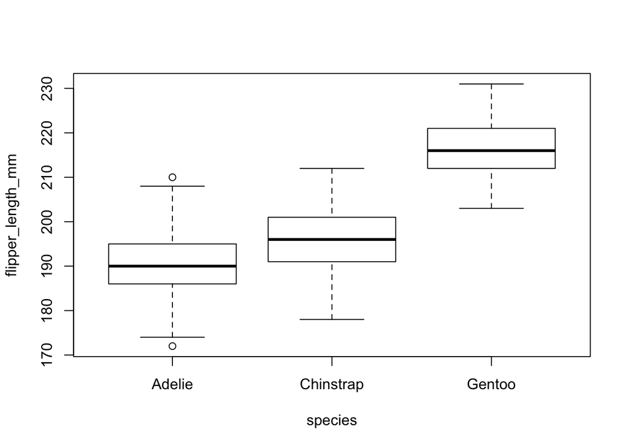

```r
boxplot(flipper_length_mm ~ species, data = penguins)
```

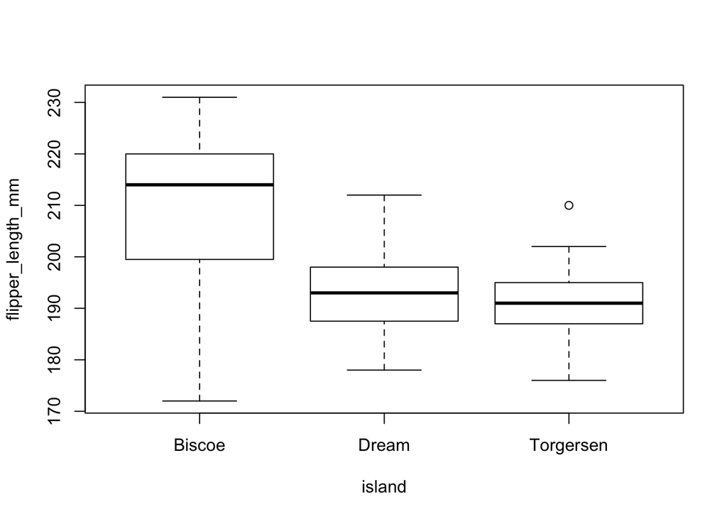

```r
boxplot(flipper_length_mm ~ island, data = penguins)
```

Extra Credit:

```r
penguins <- penguins %>%
  mutate(species_island = paste(species, island, sep = "\n"))
```

##### 3b. Show the relationship between average flipper length and average body mass by species and island. What do you see?

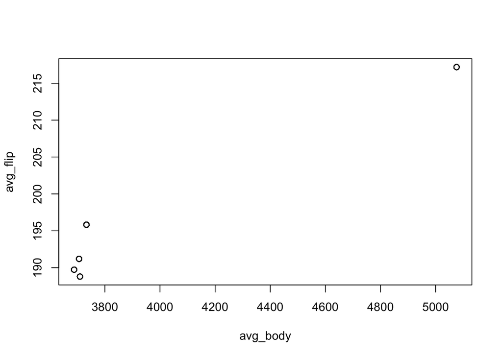

```r
penguins <- penguins %>%
  dplyr::group_by(species_island) %>%
  dplyr::mutate(avg_flip = mean(flipper_length_mm, na.rm = TRUE),
         avg_body = mean(body_mass_g, na.rm = TRUE)) %>%
  dplyr::ungroup()

plot(avg_flip ~ avg_body, data =penguins)
```

Penguins with higher body mass have larger flipper lengths.

##### 3c. Interesting. What if you had made the same plot with the whole dataset? What do you see? Is there anything that could clarify the result any more? Think about it - lots of possible right answers here.

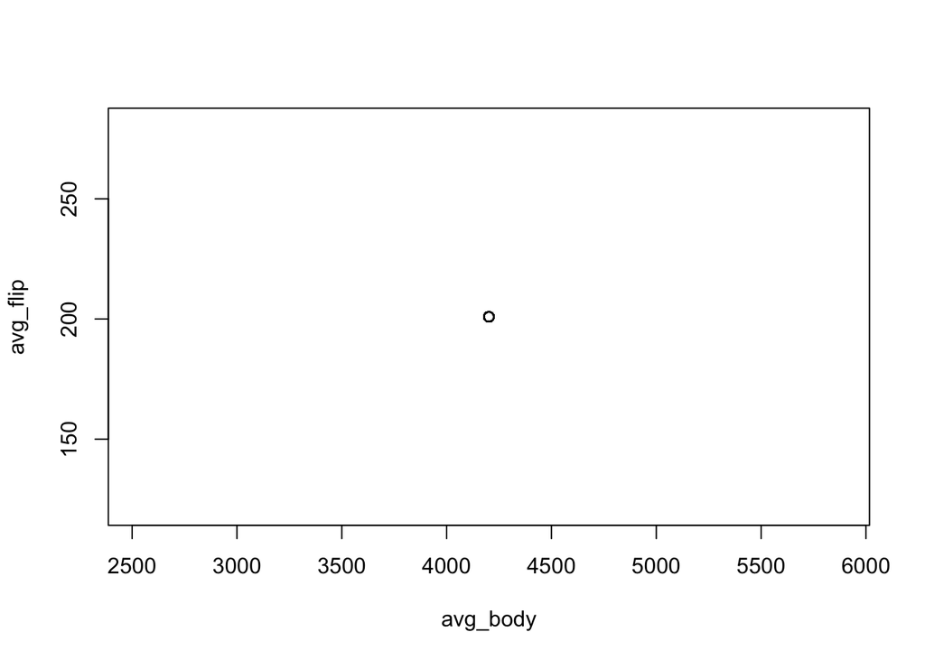

```r
penguins2 <- penguins %>%
  dplyr::mutate(avg_flip = mean(flipper_length_mm, na.rm = TRUE),
         avg_body = mean(body_mass_g, na.rm = TRUE))

plot(avg_flip ~ avg_body, data = penguins2)
```

This shows just 1 point… Coloring points by island or by species, (or by both) may clarify the results more, so we can see how they differ by island and/or species

#### 4. Let’s get ready to simulate

##### 4a. Grab the values for bill_length_mm for Gentoo penguins in Biscoe Island and put it into an object.

```r
penguins <- penguins %>%
  mutate(species_island = paste(species, island, sep = "_"))

bill_gentoo_biscoe <- penguins %>%
  filter(species_island == 'Gentoo_Biscoe') %>%
  select(bill_length_mm)
```

##### 4b. Use replicate() to calculate the standard error of the mean 10 times. Use a formula! Don’t forget that NA values shouldn’t be included!

```r
replicate(n = 10, sd(bill_gentoo_biscoe$bill_length_mm, na.rm = TRUE) / sqrt(length(bill_gentoo_biscoe$bill_length_mm)))
```

```
##  [1] 0.276759 0.276759 0.276759 0.276759 0.276759 0.276759 0.276759 0.276759
##  [9] 0.276759 0.276759
```

The SE is 0.276759

##### 4c. Use map_df() to create a data frame with the mean and sd of different sample sizes using the first 5 through 100 values (so, n = 5:100 - smallest sample size will have the values 1-5). Make sure the sample size is included in the final data frame.

```r
samp_size <- map_df(5:100, ~data.frame(avg = mean(bill_gentoo_biscoe$bill_length_mm[1:.x]),
                          sd = sd(bill_gentoo_biscoe$bill_length_mm[1:.x]),
                          sampsize = .x))
samp_size
```

```
##         avg       sd sampsize
## 1  48.48000 1.666433        5
## 2  48.15000 1.695582        6
## 3  47.75714 1.864454        7
## 4  47.62500 1.766150        8
## 5  47.14444 2.192665        9
## 6  47.11000 2.070132       10
## 7  46.54545 2.713435       11
## 8  46.75000 2.682434       12
## 9  46.65385 2.591530       13
## 10 46.77857 2.533219       14
## 11 46.71333 2.454112       15
## 12 46.87500 2.457506       16
## 13 46.58824 2.657038       17
## 14 46.73333 2.650194       18
```

[output cut: 82 more lines]

##### 4d. Plot the relationship between sample size and SD and sample size versus SE of the mean. What difference do you see and why? Note, you’ll need to create a column for SE here!

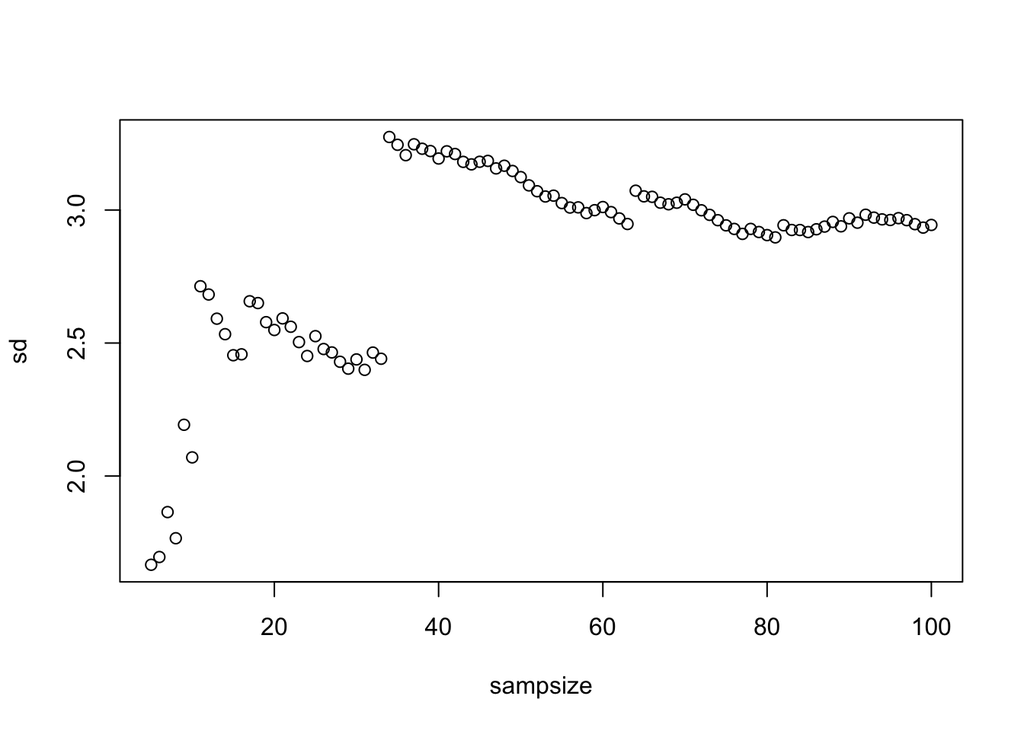

```r
plot(sd ~ sampsize, data = samp_size)
```

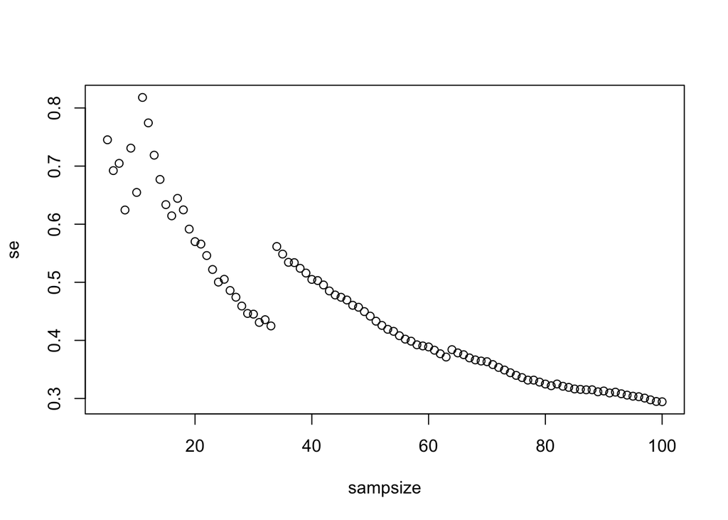

```r
samp_size_se <- map_df(5:100, ~data.frame(avg = mean(bill_gentoo_biscoe$bill_length_mm[1:.x]),
                                       sd = sd(bill_gentoo_biscoe$bill_length_mm[1:.x]),
                                       sampsize = .x,
                          se = sd(bill_gentoo_biscoe$bill_length_mm[1:.x], na.rm = TRUE) / sqrt(length(bill_gentoo_biscoe$bill_length_mm[1:.x]))))

plot(se ~ sampsize, data = samp_size_se)
```

The standard deviation is higher with higher sample size overall, but pretty consistent from sample sizes 40-100… On the other hand, the standard error appears to decrease with higher sample size.  
This is because standard deviation is a population parameter, and should not change based on sample size.  
SE is a measure of precision, and will therefore decrease as you increase sample size (because precision increases).

#### Extra Credit: Make a beautiful table showing the average properties of bills of penguins by species, sex, and island.

```r
test <- penguins %>%
  dplyr::group_by(species, sex, island) %>%
  dplyr::mutate(avg_bill_length_spec = mean(bill_length_mm, na.rm = TRUE),
         avg_bill_depth_spec = mean(bill_depth_mm, na.rm = TRUE),
         avg_bill_length_sex = mean(bill_length_mm, na.rm = TRUE),
         avg_bill_depth_sex = mean(bill_depth_mm, na.rm = TRUE),
         avg_bill_length_isl = mean(bill_length_mm, na.rm = TRUE),
         avg_bill_depth_isl = mean(bill_depth_mm, na.rm = TRUE)) %>%
  dplyr::ungroup()

tabledf_1 <- test %>%
  dplyr::filter(sex == "female" | sex == "male") %>%
  dplyr::select(species, island, sex, avg_bill_length_spec, avg_bill_depth_spec,
                avg_bill_length_sex, avg_bill_depth_sex, avg_bill_length_isl, avg_bill_depth_isl)

tabledf_3 <- dplyr::distinct(.data = tabledf_1, .keep_all = TRUE)
```

This was as beautiful as I could make it :-)

```r
kbl(tabledf_3) %>%
  kable_paper(c("hover"), full_width = F) %>%
  kable_styling(fixed_thead = TRUE) %>%
  row_spec(row = c(2,3,5,7,9), color = "white", background = "pink") %>%
    row_spec(row = c(1,4,6,8,10), color = "white", background = "cadetblue")
```

| species | island | sex | avg_bill_length_spec | avg_bill_depth_spec | avg_bill_length_sex | avg_bill_depth_sex | avg_bill_length_isl | avg_bill_depth_isl |
| --- | --- | --- | --- | --- | --- | --- | --- | --- |
| Adelie | Torgersen | male | 40.58696 | 19.39130 | 40.58696 | 19.39130 | 40.58696 | 19.39130 |
| Adelie | Torgersen | female | 37.55417 | 17.55000 | 37.55417 | 17.55000 | 37.55417 | 17.55000 |
| Adelie | Biscoe | female | 37.35909 | 17.70455 | 37.35909 | 17.70455 | 37.35909 | 17.70455 |
| Adelie | Biscoe | male | 40.59091 | 19.03636 | 40.59091 | 19.03636 | 40.59091 | 19.03636 |
| Adelie | Dream | female | 36.91111 | 17.61852 | 36.91111 | 17.61852 | 36.91111 | 17.61852 |
| Adelie | Dream | male | 40.07143 | 18.83929 | 40.07143 | 18.83929 | 40.07143 | 18.83929 |
| Gentoo | Biscoe | female | 45.56379 | 14.23793 | 45.56379 | 14.23793 | 45.56379 | 14.23793 |
| Gentoo | Biscoe | male | 49.47377 | 15.71803 | 49.47377 | 15.71803 | 49.47377 | 15.71803 |
| Chinstrap | Dream | female | 46.57353 | 17.58824 | 46.57353 | 17.58824 | 46.57353 | 17.58824 |
| Chinstrap | Dream | male | 51.09412 | 19.25294 | 51.09412 | 19.25294 | 51.09412 | 19.25294 |